# Exploratory Data Analysis

Shanmukh

April 20, 2019

# ESTIMATES OF LOCATION

**USEPAdata_017 data set**

| State Code | County Code | Site Num | Parameter Code | POC |
| --- | --- | --- | --- | --- |
| 01 | 003 | 0010 | 44201 | 1 |
| 01 | 003 | 0010 | 44201 | 1 |
| 01 | 003 | 0010 | 44201 | 1 |
| 01 | 003 | 0010 | 44201 | 1 |
| 01 | 003 | 0010 | 88101 | 1 |
| 01 | 003 | 0010 | 88101 | 1 |

#### Structure of dataset

```r
str(USEPAdata_017)
```

```
## Classes 'tbl_df', 'tbl' and 'data.frame':    66869 obs. of  55 variables:
##  $ State Code                   : chr  "01" "01" "01" "01" ...
##  $ County Code                  : chr  "003" "003" "003" "003" ...
##  $ Site Num                     : chr  "0010" "0010" "0010" "0010" ...
##  $ Parameter Code               : int  44201 44201 44201 44201 88101 88101 88101 88101 88101 88101 ...
##  $ POC                          : int  1 1 1 1 1 1 1 1 1 1 ...
##  $ Latitude                     : num  30.5 30.5 30.5 30.5 30.5 ...
##  $ Longitude                    : num  -87.9 -87.9 -87.9 -87.9 -87.9 ...
##  $ Datum                        : chr  "NAD83" "NAD83" "NAD83" "NAD83" ...
##  $ Parameter Name               : chr  "Ozone" "Ozone" "Ozone" "Ozone" ...
##  $ Sample Duration              : chr  "1 HOUR" "8-HR RUN AVG BEGIN HOUR" "8-HR RUN AVG BEGIN HOUR" "8-HR RUN AVG BEGIN HOUR" ...
##  $ Pollutant Standard           : chr  "Ozone 1-hour 1979" "Ozone 8-Hour 1997" "Ozone 8-Hour 2008" "Ozone 8-hour 2015" ...
##  $ Metric Used                  : chr  "Daily maxima of observed hourly values (between 9:00 AM and 8:00 PM)" "Daily maximum of 8 hour running average of observed hourly values" "Daily maximum of 8 hour running average of observed hourly values" "Daily maximum of 8-hour running average" ...
##  $ Method Name                  : chr  "INSTRUMENTAL - ULTRA VIOLET ABSORPTION" NA NA NA ...
##  $ Year                         : int  2017 2017 2017 2017 2017 2017 2017 2017 2017 2017 ...
##  $ Units of Measure             : chr  "Parts per million" "Parts per million" "Parts per million" "Parts per million" ...
##  $ Event Type                   : chr  "No Events" "No Events" "No Events" "No Events" ...
##  $ Observation Count            : int  5240 5426 5426 3852 110 110 110 110 118 118 ...
##  $ Observation Percent          : int  93 91 91 90 90 90 90 90 97 97 ...
##  $ Completeness Indicator       : chr  "Y" "Y" "Y" "Y" ...
##  $ Valid Day Count              : int  227 222 222 221 110 110 110 110 118 118 ...
##  $ Required Day Count           : int  245 245 245 245 122 122 122 122 122 122 ...
##  $ Exceptional Data Count       : int  0 0 0 0 0 0 0 0 0 0 ...
##  $ Null Data Count              : int  640 0 0 0 12 12 12 12 6 6 ...
##  $ Primary Exceedance Count     : int  0 0 0 1 0 0 NA NA 0 0 ...
##  $ Secondary Exceedance Count   : int  0 0 0 1 0 0 NA NA 0 0 ...
##  $ Certification Indicator      : chr  "Certified" "Certified" "Certified" "Certified" ...
##  $ Num Obs Below MDL            : int  0 0 0 0 0 0 0 0 0 0 ...
##  $ Arithmetic Mean              : num  0.0443 0.0401 0.0401 0.0399 7.3918 ...
##  $ Arithmetic Standard Dev      : num  0.0122 0.0116 0.0116 0.0116 3.5723 ...
##  $ 1st Max Value                : num  0.078 0.073 0.073 0.073 19.7 19.7 19.7 19.7 19 19 ...
##  $ 1st Max DateTime             : POSIXct, format: "2017-05-08 15:00:00" "2017-05-08 14:00:00" ...
##  $ 2nd Max Value                : num  0.078 0.07 0.07 0.07 18.9 18.9 18.9 18.9 17.4 17.4 ...
##  $ 2nd Max DateTime             : POSIXct, format: "2017-05-09 14:00:00" "2017-05-09 09:00:00" ...
##  $ 3rd Max Value                : num  0.072 0.067 0.067 0.067 18.9 18.9 18.9 18.9 16.8 16.8 ...
##  $ 3rd Max DateTime             : POSIXct, format: "2017-05-10 14:00:00" "2017-05-10 09:00:00" ...
##  $ 4th Max Value                : num  0.067 0.064 0.064 0.064 16 16 16 16 16.3 16.3 ...
##  $ 4th Max DateTime             : POSIXct, format: "2017-04-25 15:00:00" "2017-05-07 13:00:00" ...
##  $ 1st Max Non Overlapping Value: num  NA NA NA NA NA NA NA NA NA NA ...
##  $ 1st NO Max DateTime          : POSIXct, format: NA NA ...
```

[output cut: 123 more lines]

[output not shown]

### Mean

```
- The sum of all values divided by the number of values.

- The mean() function computes the arithmetic mean.

- arguments:X, na.rm= FALSE,trim =0

- default value exists for na.rm and trim hence not mandatory

- trim denotes trimming the start and end values 0.1 denotes 10% trim in starting and ending.
```

```r
mean(USEPAdata_017$`Valid Day Count`,na.rm = TRUE) # na.rm ignores NA values
```

```
## [1] 155.8299
```

### Weighted mean

```
- The sum of all values times a weight divided by the sum of the weights.
```

```r
weighted.mean(mtcars$mpg,w=mtcars$wt)
```

```
## [1] 18.54993
```

### Median

```
- The value such that one-half of the data lies above and below.
```

```r
median(USEPAdata_017$`Valid Day Count`,na.rm = TRUE)# na.rm ignores NA values
```

```
## [1] 113
```

### Weighted median

```
- The value such that one-half of the sum of the weights lies above and below the sorted data.
```

```r
weightedMedian(mtcars$mpg,w=mtcars$wt)
```

```
## [1] 17.89148
```

### Trimmed mean

```
- The average of all values after dropping a fixed number of extreme values.
```

```r
mean(USEPAdata_017$`Valid Day Count`,na.rm = TRUE,trim=0.1)# na.rm ignores NA values
```

```
## [1] 147.3887
```

# VARIABILITY METRICS

### Variance

- The sum of squared deviations from the mean divided by n - 1 where n is the number of data values.

```r
var(USEPAdata_017$`Valid Day Count`,na.rm = TRUE)# na.rm ignores NA values
```

```
## [1] 16273.86
```

### Standard deviation

- The square root of the variance.

```r
sd(USEPAdata_017$`Valid Day Count`,na.rm = TRUE)# na.rm ignores NA values
```

```
## [1] 127.569
```

### Mean absolute deviation

- The mean of the absolute value of the deviations from the mean.

```r
MeanAD(USEPAdata_017$`Valid Day Count`,na.rm = TRUE)# na.rm ignores NA values
```

```
## [1] 113.6896
```

### Median absolute deviation from the median

- The median of the absolute value of the deviations from the median.

```r
mad(USEPAdata_017$`Valid Day Count`,na.rm = TRUE)
```

```
## [1] 90.4386
```

### Range

- The difference between the largest and the smallest value in a data set.

```r
range(USEPAdata_017$`Valid Day Count`,na.rm = TRUE)# na.rm ignores NA values
```

```
## [1]   0 365
```

```r
# diff gives difference between maximum and minimum values of the range

diff(range(USEPAdata_017$`Valid Day Count`,na.rm = TRUE))# na.rm ignores NA values
```

```
## [1] 365
```

### Interquartile range

- The difference between the 75th percentile and the 25th percentile.

```r
IQR(USEPAdata_017$`Valid Day Count`,na.rm = TRUE)
```

```
## [1] 255
```

# EXPLORING THE DISTRIBUTION

### Boxplot

- A plot introduced by Tukey as a quick way to visualize the distribution of data.

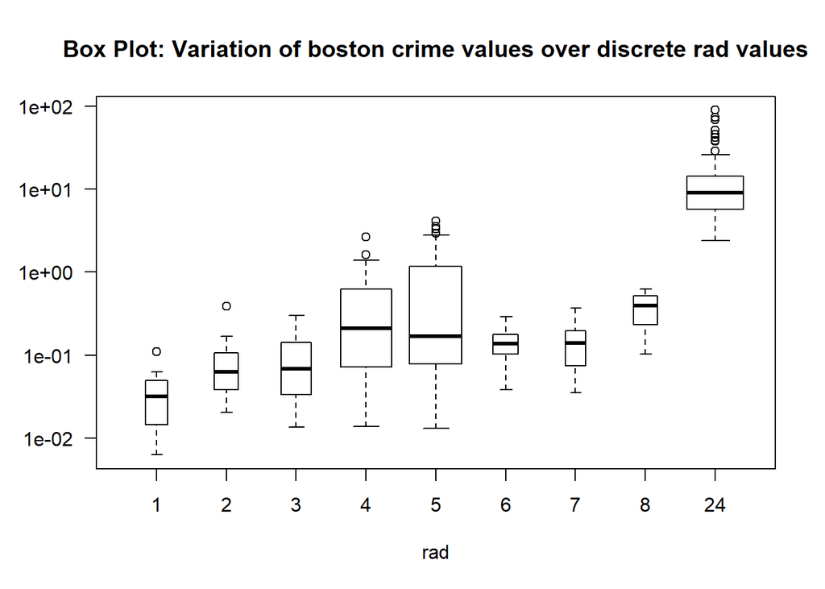

```r
boxplot(crim~rad,data=Boston,log="y",las=1,varwidth=TRUE,
        xlab="rad",
main ="Box Plot: Variation of boston crime values over discrete rad values")
```

### Frequency table

- A tally of the count of numeric data values that fall into a set of intervals (bins).

```r
  freq(Cars93$Manufacturer)
```

```
## $`x:`
##                      x label Freq Percent Valid Percent Cumulative Percent
## 2     Valid      Acura          2     2.2           2.2                2.2
## 3                 Audi          2     2.2           2.2                4.3
## 4                  BMW          1     1.1           1.1                5.4
## 5                Buick          4     4.3           4.3                9.7
## 6             Cadillac          2     2.2           2.2               11.8
## 7            Chevrolet          8     8.6           8.6               20.4
## 8             Chrylser          1     1.1           1.1               21.5
## 9             Chrysler          2     2.2           2.2               23.7
## 10               Dodge          6     6.5           6.5               30.1
## 11               Eagle          2     2.2           2.2               32.3
## 12                Ford          8     8.6           8.6               40.9
## 13                 Geo          2     2.2           2.2               43.0
## 14               Honda          3     3.2           3.2               46.2
```

[output cut: 19 more lines]

### Histogram

- A plot of the frequency table with the bins on the x-axis and the count (or proportion) on the y-axis.

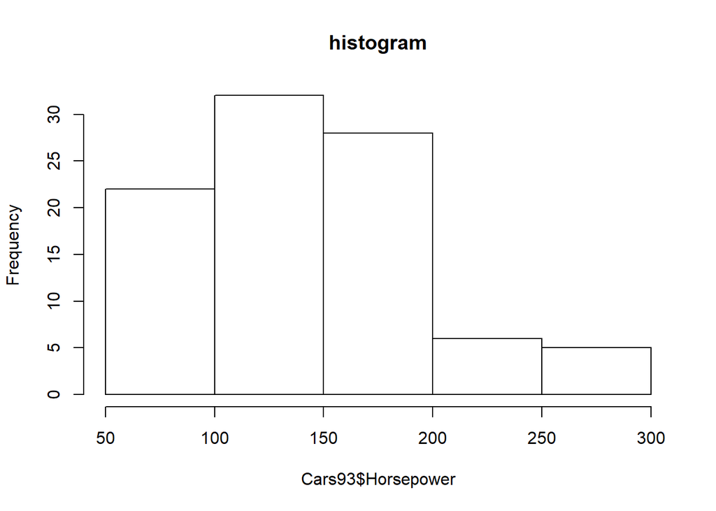

```r
hist(Cars93$Horsepower,
main="histogram")
```

### Density plot

- A smoothed version of the histogram, often based on a kernel density estimate.

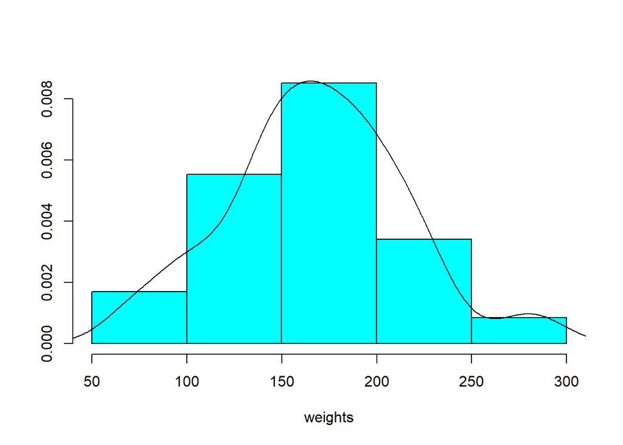

```r
# Create index16, pointing to 16-week chicks
index16<-which(ChickWeight$Time==16)

# Get the 16-week chick weights
weights <- (ChickWeight$weight[ChickWeight$Time==16])

# Plot the normalized histogram
truehist(weights)

# Add the density curve to the histogram
lines(density(weights))
```

# CORRELATION

### Correlation coefficient

- A metric that measures the extent to which numeric variables are associated with one another (ranges from -1 to +1).

### Correlation matrix

- A table where the variables are shown on both rows and columns, and the cell values are the correlations between the variables.

```r
cor(mtcars)# Provides correlation values
```

```
##             mpg        cyl       disp         hp        drat         wt
## mpg   1.0000000 -0.8521620 -0.8475514 -0.7761684  0.68117191 -0.8676594
## cyl  -0.8521620  1.0000000  0.9020329  0.8324475 -0.69993811  0.7824958
## disp -0.8475514  0.9020329  1.0000000  0.7909486 -0.71021393  0.8879799
## hp   -0.7761684  0.8324475  0.7909486  1.0000000 -0.44875912  0.6587479
## drat  0.6811719 -0.6999381 -0.7102139 -0.4487591  1.00000000 -0.7124406
## wt   -0.8676594  0.7824958  0.8879799  0.6587479 -0.71244065  1.0000000
## qsec  0.4186840 -0.5912421 -0.4336979 -0.7082234  0.09120476 -0.1747159
## vs    0.6640389 -0.8108118 -0.7104159 -0.7230967  0.44027846 -0.5549157
## am    0.5998324 -0.5226070 -0.5912270 -0.2432043  0.71271113 -0.6924953
## gear  0.4802848 -0.4926866 -0.5555692 -0.1257043  0.69961013 -0.5832870
## carb -0.5509251  0.5269883  0.3949769  0.7498125 -0.09078980  0.4276059
##             qsec         vs          am       gear        carb
## mpg   0.41868403  0.6640389  0.59983243  0.4802848 -0.55092507
## cyl  -0.59124207 -0.8108118 -0.52260705 -0.4926866  0.52698829
## disp -0.43369788 -0.7104159 -0.59122704 -0.5555692  0.39497686
## hp   -0.70822339 -0.7230967 -0.24320426 -0.1257043  0.74981247
## drat  0.09120476  0.4402785  0.71271113  0.6996101 -0.09078980
## wt   -0.17471588 -0.5549157 -0.69249526 -0.5832870  0.42760594
## qsec  1.00000000  0.7445354 -0.22986086 -0.2126822 -0.65624923
## vs    0.74453544  1.0000000  0.16834512  0.2060233 -0.56960714
## am   -0.22986086  0.1683451  1.00000000  0.7940588  0.05753435
## gear -0.21268223  0.2060233  0.79405876  1.0000000  0.27407284
## carb -0.65624923 -0.5696071  0.05753435  0.2740728  1.00000000
```

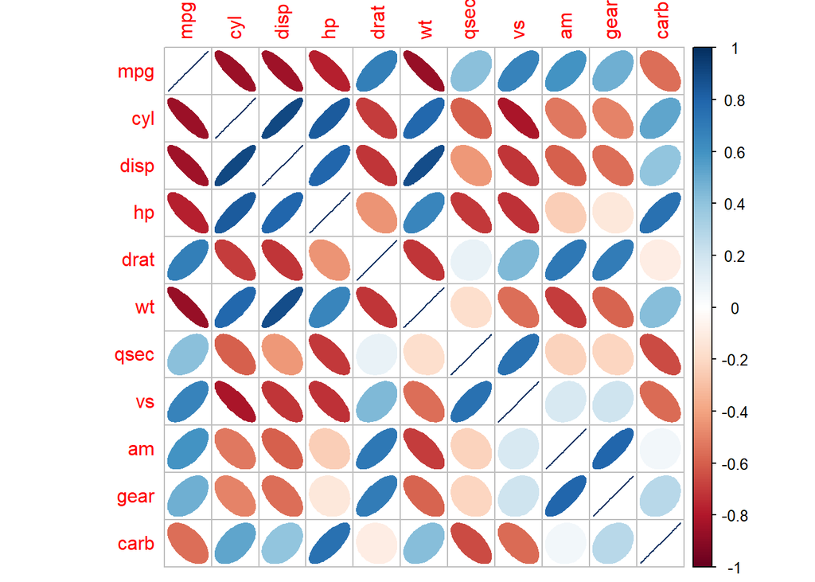

```r
corrplot(cor(mtcars),method="ellipse")
```

### Scatterplot

- A plot in which the x-axis is the value of one variable, and the y-axis the value of another.

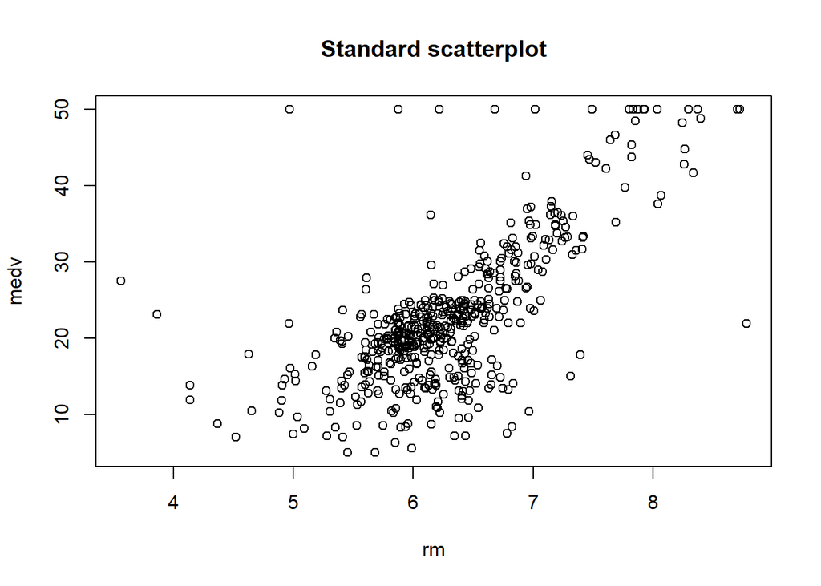

```r
plot(medv~rm,data=Boston)
title("Standard scatterplot")
```

**Referred from oreilly.com** [Link](https://www.oreilly.com/library/view/practical-statistics-for/9781491952955/ch01.html)